# Practical Machine Learning Course Project

Timothy Chen Allen

December 25, 2015

## Purpose and Data Source

This study uses **Human Activity Recognition** data (Velloso et al, 2013), collected from six exercisers equipped with accelerometers, to create and test a prediction function to predict exercise quality based on data from the accelerometers. This is a classification problem.

## GitHub Repository

https://github.com/TimothyChenAllen/practicalmachinelearning

## Expected Out-of-Sample Error

Out-of-sample error of the most parsimonious prediction function, using only 18 features, is estimated to be less than 1% (0.76%), with a cross-validated accuracy of 99.2% (from `caret::confusionMatrix`).

## Method

1. **Split Datasets**. Three datasets are used: the original training dataset is split into a `training` and `testing` set. The original testing dataset is held aside as the `validation` set.
2. **Define Error Rate**. Accuracy of predictions on the `training` set is used to select covariates. Cross-validated accuracy of predictions on the `testing` set is used to refine the final model, which is used one time only on the `validation` dataset.
3. **Pick Features and Cross Validate**. Initially, 53 of the 160 columns are used as features. Features are retained which a) are readings from the accelerometers, b) do not have large amounts of missing data, and c) do not have Near Zero Variability. Cross-validation is done on the `testing` dataset to determine if the features retained are useful.
4. **Pick Prediction Function**. *Random Forest* is trained using the `training` dataset, as it gives good accuracy on classification problems. The trained prediction function is cross-validated using the `testing` data set.
5. **Refine prediction function, seeking parsimony**. The `training` and `testing` datasets are used to find the smallest number of predictor features that return a good error rate. This avoids overfitting and improves robustness. The final prediction function is trained and corss-validated using a set of only 18 predictor features, while retaining good estimated out-of-sample error and accuracy.
6. **Validate final prediction function**. Predictions are made using the `validation` dataset and submitted for grading.

## Load libraries

```r
require(caret)
require(rpart)
require(dplyr)
require(randomForest)
require(e1071)
require(rpart)
```

## Split data into training, testing, and validation sets

Three datasets are used: the original training dataset is split into a `training` and `testing` set. The original testing dataset is held aside as the `validation` set.

```r
if (file.exists("raw_training.sav")) {
  load("raw_training.sav")
  load("validation.sav")
} else {
  raw_training <- read.csv("https://d396qusza40orc.cloudfront.net/predmachlearn/pml-training.csv")
  save(raw_training, file="raw_training.sav")
  validation <- read.csv("https://d396qusza40orc.cloudfront.net/predmachlearn/pml-testing.csv")
  save(validation, file="validation.sav")
}

# Create a training and testing set from the training data
set.seed(42)
inTrain <- createDataPartition(y=raw_training$classe, p=0.7, list=FALSE)
training <- raw_training[inTrain,]
testing <- raw_training[-inTrain,]
# Now we have a training set, a testing set, and a validation set
```

## Pick features and cross-validate (training set)

Initially, 53 of the 160 columns are used as features. Features are retained which a) are readings from the accelerometers, b) do not have large amounts of missing data, and c) do not have Near Zero Variability. Cross-validation is done on the `testing` dataset to determine if the features retained are useful. Later, a more parsimonious set of only 18 features is used to create and cross-validate the final prediction function.

```r
# Choose Useful Covariates
# 1) remove predictors that include NAs, and columns that are unique for the user/instance
training.important <- training[,!unlist(lapply(training, function(x) any(is.na(x))))]

# 2) use nearZeroVar function to exclude columns without sufficient variance
nz.table <- nearZeroVar(training.important, saveMetrics=TRUE)
keep.columns <- row.names(nz.table[!nz.table$nzv,])

# 3) Remove columns that identify individual records
keep.columns <- keep.columns[is.na(match(
  keep.columns,
  c(
    "X", "user_name", "raw_timestamp_part_1", "raw_timestamp_part_2",
    "cvtd_timestamp", "num_window"
  )
))]

# Retain important features in both the training and testing datasets
training.important <- training %>% select(match(keep.columns, names(training)))
```

## Pick the prediction function and cross-validate

*Random Forest* is trained using the resulting subset of features in the `training` dataset, as it gives good accuracy on classification problems. The trained prediction function is cross-validated using the `testing` data set.

```r
rf <- randomForest(classe ~ . -classe, data=training.important, ntree=200 )
```

## Apply Features and Prediction Function to Test set

```r
# predict outcome for test data set using the random forest model
pred.important <- predict(rf,testing)
# compare results to testing set - Accuracy
confusionMatrix(testing$classe, pred.important)
```

```
## Confusion Matrix and Statistics
##
##           Reference
## Prediction    A    B    C    D    E
##          A 1672    2    0    0    0
##          B    4 1126    9    0    0
##          C    0    7 1018    1    0
##          D    0    0   14  950    0
##          E    0    0    0    0 1082
##
## Overall Statistics
##
##                Accuracy : 0.9937
##                  95% CI : (0.9913, 0.9956)
##     No Information Rate : 0.2848
##     P-Value [Acc > NIR] : < 2.2e-16
##
##                   Kappa : 0.992
##  Mcnemar's Test P-Value : NA
##
## Statistics by Class:
##
##                      Class: A Class: B Class: C Class: D Class: E
## Sensitivity            0.9976   0.9921   0.9779   0.9989   1.0000
## Specificity            0.9995   0.9973   0.9983   0.9972   1.0000
## Pos Pred Value         0.9988   0.9886   0.9922   0.9855   1.0000
## Neg Pred Value         0.9991   0.9981   0.9953   0.9998   1.0000
## Prevalence             0.2848   0.1929   0.1769   0.1616   0.1839
## Detection Rate         0.2841   0.1913   0.1730   0.1614   0.1839
## Detection Prevalence   0.2845   0.1935   0.1743   0.1638   0.1839
## Balanced Accuracy      0.9986   0.9947   0.9881   0.9981   1.0000
```

## Refine the Features to Seek Parsimony

Use `caret::varImp` to determine the most parsimonious set of features that retains a good error rate. Reducing the number of features from 53 to 18 retains a cross-validated accuracy of 99.2% and an estimated Out-of-Sample error of less than 1% (0.76%) from `caret::confusionMatrix`.

```r
# Important variables
importance <- varImp(rf)
important.features <- importance %>% mutate(nm=rownames(importance)) %>% arrange(desc(Overall))

training.parsimony <- training.important[,match(c("classe",important.features[1:18,]$nm),
                                                names(training.important))]

# Try a more parsimonious model based on these importance values
(rf.parsimony <- randomForest(classe ~ ., data=training.parsimony, ntree=200 ))
```

```
##
## Call:
##  randomForest(formula = classe ~ ., data = training.parsimony,      ntree = 200)
##                Type of random forest: classification
##                      Number of trees: 200
## No. of variables tried at each split: 4
##
##         OOB estimate of  error rate: 0.76%
## Confusion matrix:
##      A    B    C    D    E class.error
## A 3895    7    1    2    1 0.002816180
## B   14 2628   15    1    0 0.011286682
## C    0   15 2368   13    0 0.011686144
## D    0    0   20 2230    2 0.009769094
## E    0    1    3    9 2512 0.005148515
```

```r
# predict outcome for test data set using the random forest model
pred.parsimony <- predict(rf.parsimony,testing)
# Show confusion matrix of prediction function
confusionMatrix(pred.parsimony, testing$classe)
```

```
## Confusion Matrix and Statistics
##
##           Reference
## Prediction    A    B    C    D    E
##          A 1668    4    0    0    0
##          B    3 1121    6    0    0
##          C    0   13 1019   15    1
##          D    3    1    1  949    0
##          E    0    0    0    0 1081
##
## Overall Statistics
##
##                Accuracy : 0.992
##                  95% CI : (0.9894, 0.9941)
##     No Information Rate : 0.2845
##     P-Value [Acc > NIR] : < 2.2e-16
##
##                   Kappa : 0.9899
##  Mcnemar's Test P-Value : NA
##
## Statistics by Class:
##
##                      Class: A Class: B Class: C Class: D Class: E
## Sensitivity            0.9964   0.9842   0.9932   0.9844   0.9991
## Specificity            0.9991   0.9981   0.9940   0.9990   1.0000
## Pos Pred Value         0.9976   0.9920   0.9723   0.9948   1.0000
## Neg Pred Value         0.9986   0.9962   0.9986   0.9970   0.9998
## Prevalence             0.2845   0.1935   0.1743   0.1638   0.1839
## Detection Rate         0.2834   0.1905   0.1732   0.1613   0.1837
## Detection Prevalence   0.2841   0.1920   0.1781   0.1621   0.1837
## Balanced Accuracy      0.9977   0.9912   0.9936   0.9917   0.9995
```

## Graphical Representation of Parsimonious Features

The following graphic gives some idea of how `classe` is grouped by the two most importat features used to train the prediction function (as indicated by `caret::varImp`). In reality, 18 features were used to train the random forest.

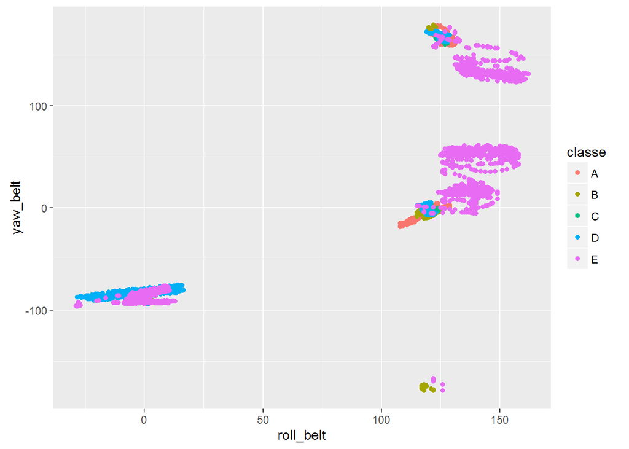

## Apply Prediction Function to Validation Dataset

Apply refined features and prediction function to validation set.  
Out-of-sample error of the most parsimonious prediction function is estimated to be less than 1% (0.76%), with a cross-validated accuracy of 99.2% (from `caret::confusionMatrix`). In practice, 20 predictions, based on the `validation` dataset, were uploaded for grading and found to be 100% accurate.

```r
pred.validation <- predict(rf.parsimony,validation)
```

## References

Velloso, E.; Bulling, A.; Gellersen, H.; Ugulino, W.; Fuks, H. **Qualitative Activity Recognition of Weight Lifting Exercises**. Proceedings of 4th International Conference in Cooperation with SIGCHI (Augmented Human ’13) . Stuttgart, Germany: ACM SIGCHI, 2013.

Read more: http://groupware.les.inf.puc-rio.br/har